# Pandemic Tweet Analysis

4/8/2022

## Project Goals

The goal of our project is to see what people are saying about the pandemic in current times. We want to see if people are still being careful or if they have started treating the pandemic as a part of everyday life. We also want to explore using twitter data.

## Scraping the data

Here we will use the rtweet package to obtain a number of recent tweets that have the keyword “pandemic”. We query the most recent tweets. We also created another tibble where we filter for comments with more than 10 likes.

```r
rt <- search_tweets(
  q="pandemic", n = 10000, type = "recent", include_rts = FALSE
)
rt<-rt%>%select("text", "favorite_count")
rt%>%arrange(desc(favorite_count))%>%head()
```

```
## # A tibble: 6 × 2
##   text                                                            favorite_count
##   <chr>                                                                    <int>
## 1 "A new study based on Moderna’s Phase 3 clinical trial data su…           1529
## 2 "We warned you that the pandemic was an agenda to wreck the ec…            916
## 3 "I’ve had a great day- so enjoyed being part of the celebratio…            439
## 4 "@narendramodi ji @PMOIndia sir we post these past tweets remi…            379
## 5 "4.7 million people died of Covid in India, 10 times the offic…            324
## 6 "Covid killed about one out of every 500 people globally in th…            287
```

```r
rt2<-rt%>%filter(favorite_count>10)
```

Here we write the data to a csv.

```r
write.csv(rt, 'pandemic_tweets.csv')
```

## Top 10 words

Here we tidy the data and display the top 10 used words.

```r
tidy_rt <- rt %>%
  unnest_tokens(word, text) %>%
  mutate(word = str_extract(word, "[a-z]+")) %>%
  filter(!(word=="NA"))%>%
  anti_join(stop_words)
tidy_rt %>%
  count(word, sort = TRUE)%>%head(10)
```

```
## # A tibble: 10 × 2
##    word              n
##    <chr>         <int>
##  1 pandemic       7727
##  2 https          5080
##  3 covid          1843
##  4 home            991
##  5 people          966
##  6 million         821
##  7 williamchurch   816
##  8 amp             719
##  9 world           647
## 10 death           557
```

Here we do the same for the tibble only including tweets with more than 10 likes

```r
tidy_rt2 <- rt2 %>%
  unnest_tokens(word, text) %>%
  mutate(word = str_extract(word, "[a-z]+")) %>%
  filter(!(word=="NA"))%>%
  anti_join(stop_words)
tidy_rt2 %>%
  count(word, sort = TRUE)%>%head(10)
```

```
## # A tibble: 10 × 2
##    word         n
##    <chr>    <int>
##  1 pandemic   307
##  2 https      224
##  3 covid       80
##  4 people      55
##  5 deaths      45
##  6 million     44
##  7 amp         37
##  8 health      25
##  9 time        22
## 10 excess      21
```

## Top 10 bigrams

Here we display the top 10 bigrams.

```r
tidy_rt_bigram <- rt %>%
  unnest_tokens(bigram, text, token = "ngrams", n = 2)%>%
filter(bigram != "NA")
tidy_rt_bigram %>%
  separate(bigram, c("word1", "word2"), sep = " ") %>%
  mutate(word1 = str_extract(word1, "[a-z]+")) %>%
  mutate(word2 = str_extract(word2, "[a-z]+")) %>%
  filter(!word1 %in% stop_words$word) %>%
  filter(!word2 %in% stop_words$word)%>%
  filter(!(word1=="NA"|word2=="NA"))%>%
  unite(bigram, word1, word2, sep=" ")%>%
  count(bigram, sort = TRUE)%>%head(10)
```

```
## # A tibble: 10 × 2
##    bigram                n
##    <chr>             <int>
##  1 death toll          436
##  2 pandemic https      415
##  3 isn easy            409
##  4 bitcoin trading     408
##  5 home isn            408
##  6 met williamchurch   408
##  7 started bitcoin     408
##  8 covid pandemic      271
##  9 pandemic death      266
## 10 true pandemic       238
```

Here we do the same for the tibble only including tweets with more than 10 likes

```r
tidy_rt_bigram <- rt2 %>%
  unnest_tokens(bigram, text, token = "ngrams", n = 2)%>%
filter(bigram != "NA")
tidy_rt_bigram %>%
  separate(bigram, c("word1", "word2"), sep = " ") %>%
  mutate(word1 = str_extract(word1, "[a-z]+")) %>%
  mutate(word2 = str_extract(word2, "[a-z]+")) %>%
  filter(!word1 %in% stop_words$word) %>%
  filter(!word2 %in% stop_words$word)%>%
  filter(!(word1=="NA"|word2=="NA"))%>%
  unite(bigram, word1, word2, sep=" ")%>%
  count(bigram, sort = TRUE)%>%head(10)
```

```
## # A tibble: 10 × 2
##    bigram             n
##    <chr>          <int>
##  1 pandemic https    18
##  2 covid pandemic    11
##  3 death toll        11
##  4 excess deaths     11
##  5 million people    11
##  6 covid deaths       7
##  7 million deaths     6
##  8 million excess     6
##  9 people died        6
## 10 pro life           6
```

## Sentiments

Here we do NRC sentiment analysis where we look at the top used words that are categorized into joy, sadness, anger, fear, and trust.

```r
nrc_joy <- get_sentiments("nrc") %>%
  filter(sentiment == "joy")
nrc_sad <- get_sentiments("nrc") %>%
  filter(sentiment == "sadness")
nrc_anger <- get_sentiments("nrc") %>%
  filter(sentiment == "anger")
nrc_fear <- get_sentiments("nrc") %>%
  filter(sentiment == "fear")
nrc_trust <- get_sentiments("nrc") %>%
  filter(sentiment == "trust")
tidy_rt %>%
  inner_join(nrc_joy) %>%
  count(word, sort = TRUE)%>%head()
```

```
## # A tibble: 6 × 2
##   word             n
##   <chr>        <int>
## 1 money          541
## 2 true           324
## 3 hope            95
## 4 pay             91
## 5 organization    79
## 6 food            78
```

```r
tidy_rt %>%
  inner_join(nrc_sad) %>%
  count(word, sort = TRUE)%>%head()
```

```
## # A tibble: 6 × 2
##   word         n
##   <chr>    <int>
## 1 pandemic  7727
## 2 death      557
## 3 lost       542
## 4 bad         78
## 5 worse       68
## 6 disease     62
```

```r
tidy_rt %>%
  inner_join(nrc_anger) %>%
  count(word, sort = TRUE)%>%head()
```

```
## # A tibble: 6 × 2
##   word        n
##   <chr>   <int>
## 1 death     557
## 2 money     541
## 3 hit        96
## 4 bad        78
## 5 demand     75
## 6 disease    62
```

```r
tidy_rt %>%
  inner_join(nrc_fear) %>%
  count(word, sort = TRUE)%>%head()
```

```
## # A tibble: 6 × 2
##   word           n
##   <chr>      <int>
## 1 pandemic    7727
## 2 death        557
## 3 government   184
## 4 war          179
## 5 inflation    167
## 6 change        83
```

```r
tidy_rt %>%
  inner_join(nrc_trust) %>%
  count(word, sort = TRUE)%>%head()
```

```
## # A tibble: 6 × 2
##   word        n
##   <chr>   <int>
## 1 money     541
## 2 provide   444
## 3 true      324
## 4 don       307
## 5 top       129
## 6 economy   127
```

## Plotting sentiment against favorite_count

Here we plot the total sentiment of the tweet against how many likes it got for both tibbles. We want to see if popular tweets had more a positive or a more negative vibe. This information could be helpful in trying to make a popular tweet.

```r
get_sentiment_total<-function(positive, negative){
  ret<-c()
  for(num in 1:length(positive)){
    pos<-positive[num]
    neg<-negative[num]
    if(is.na(pos) && is.na(neg)){
      ret<-append(ret, 0)
    }
    else if(is.na(pos)){
      ret<-append(ret, -1*neg)
    }
    else if (is.na(neg)){
      ret<-append(ret, pos)
    }
    else{
      ret<-append(ret, pos-neg)
    }
  }
  return(ret)
}
sentiment <- tidy_rt %>%
  inner_join(get_sentiments("bing")) %>%
  count(favorite_count, sentiment) %>%
  pivot_wider(names_from = "sentiment", values_from = "n") %>%
  mutate(sentiment = get_sentiment_total(positive, negative))
```

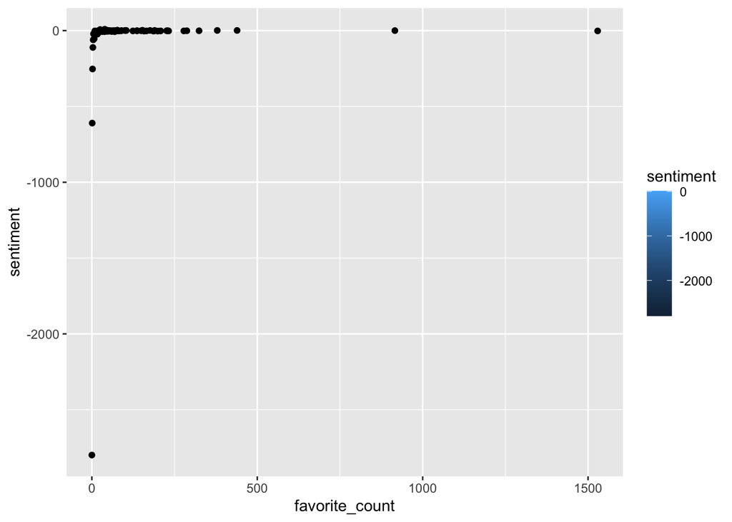

```r
ggplot(sentiment, aes(favorite_count, sentiment, fill = sentiment)) +
  geom_point()
```

```r
sentiment <- tidy_rt2 %>%
  inner_join(get_sentiments("bing")) %>%
  count(favorite_count, sentiment) %>%
  pivot_wider(names_from = "sentiment", values_from = "n") %>%
  mutate(sentiment = get_sentiment_total(positive, negative))
```

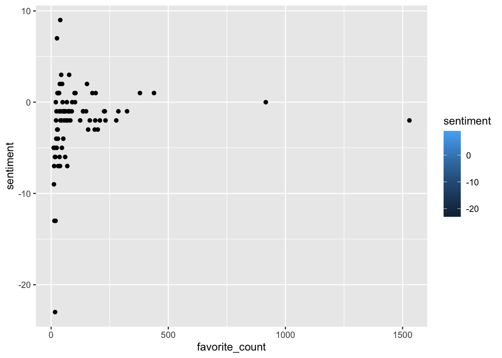

```r
ggplot(sentiment, aes(favorite_count, sentiment, fill = sentiment)) +
  geom_point()
```